# Evaluating Youtube Ads encountered by users

This analysis explores YouTube advertisements, focusing on features such as whether the ad is skippable, its length, and the type of content being promoted. The effectiveness of the ads on individuals (myself) can be observed by comparing how relevant the advertisements are using the data collected. It can help give insights into which format and content is relevant to me, whether it was engaging or intrusive.

## The comparison of how relavent skippable and non-skippable Youtube ads are

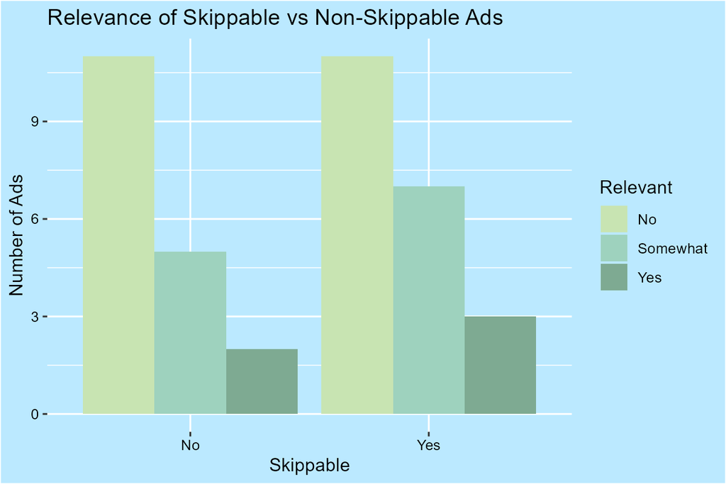

Compares how relavent Ads are by whether they are skippable or not, by using a bar graph to show them side by side

This graph compares how relevant skippable and unskippable advertisements are, which is crucial to gauging effective engagement with viewers.

## How different are the lengths and median length of Ads by catagory

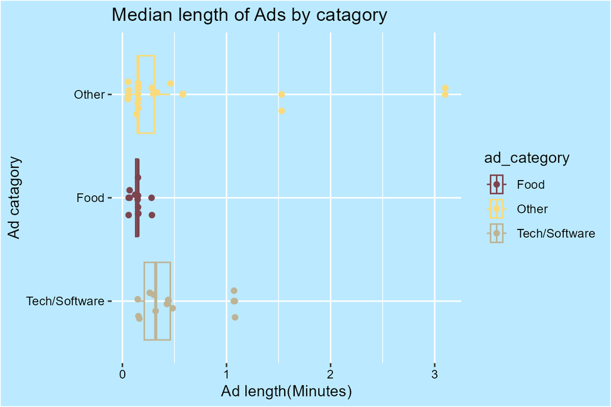

Shows the various lengths of ads by three catagories using a jitter plot, then adding a box plot to show the median value

This combines a box plot and a jitter plot to show the variation of advertisement lengths. There is a clear pattern in regard to food ads, which tend to be short and around 10 to 20 seconds. Which I found effective personally, likely due to it not interrupting much and is appealing to look at.

## The spread of skippable versus non-skippable ads across the dates they were collected

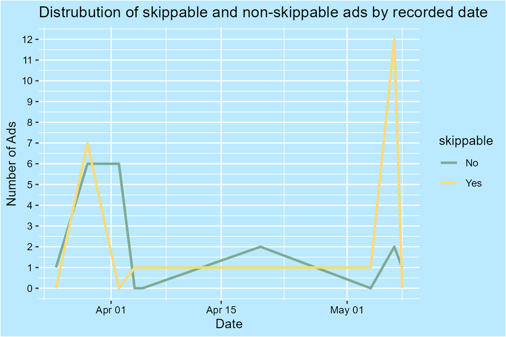

It shows whether the advertisement was skippable using a line graph across the time period the data was collected. In May, when a lot of ad data was collected, there were considerable amounts of skippable ads.